# Optimización

Al igual que en las funciones de una variable es posible, mediante derivadas, hallar los valores extremos de una función, se debe seguir un procedimiento similar, obviamente guardando las diferencias.

## Puntos críticos

Vamos a considerar una función $f$ que dependa de $n$ variables reales y su imagen sea también un número real, $n=2,\ 3,\ \ldots$, y definiremos un vector muy especial conocido como el **gradiente de $f$** notado como $\nabla f$ $$\nabla f(x_1,x_2,\ldots,x_n)=\left(\frac{\partial f}{\partial x_1}, \frac{\partial f}{\partial x_2},\ldots,\frac{\partial f}{\partial x_n}\right)$$ el cual es un vector conformado por las primeras derivadas, respecto a todas las variables de la función $f$.

De manera análoga a lo que sucede en una variable, los candidatos a ser mínimos o máximos de una función son aquellos conocidos como puntos críticos los cuales se pueden definir como sigue:

Un elemento de $\mathbb{R}^n$ $(a_1,a_2,\ldots,a_n)$ es un **punto crítico** de $f(x_1,x_2,\ldots,x_n)$ si: todas las entradas vel vector gradiente se anulan, es decir, $$\nabla f(a_1,a_2,\ldots,a_n)=(0,0,\ldots,0).$$

### Ejemplos

1. Halle los puntos críticos de $f(x,y)=x^2+y^2.$

#### Solución:

Para hallar los puntos críticos lo primero que debe hacerse es hallar las derivadas parciales de primer orden de la función $f$.

$f_x(x,y)=2x$

$f_y(x,y)=2y$

El siguiente paso es igualar ambas ecuaciones a cero:

$$\left\{ \begin{array}{l} 2x=0\\ 2y=0 \end{array} \right.$$

al despejar obtenemos un único punto crítico $x=0$ y $y=0$, es decir, la pareja ordenada $(0,0)$ es el punto crítico de la función.

1. Una empresa dedicada a la exportación, se dedica a comercializar tres productos, A, B y C, los precios de venta son $x,\ y$ y $z$ respectivamente. Se ha logrado determinar que la utilidad de la empresa viene dada por la función $$U(x,y,z)=-2x^2-4y^2-2z^3+2xy+150z+32x+54y+12$$

#### Solución:

Lo primero es calcular las derivadas parciales de primer orden

$U_x(x,y,z)=-4x+2y+32$

$U_y(x,y,z)=-8y+2x+54$

$U_z(x,y,z)=-6z^2+150$

De modo que el sistema que se debe solucionar es el siguiente: $$\begin{cases}-4x+2y+32=0\\ 2x-8y+54=0\\ -6z^2+150=0 \end{cases}$$

De las dos primeras ecuaciones se obtiene fácilmente que $x=13$ y $y=10$, mientras que de la última se obtiene que $z=5$, el valor negativo se descarta ya que no tiene sentido en el contexto.

Por lo tanto el punto crítico de la función es $(13,10,5)$.

### Ejercicios

Halle los puntos críticos de las funciones:

1. $f(x,y)=x^2+2y^2-2x-2y+1$.
2. $g(x,y)=x^2+4xy+y^2$.
3. $h(x,y)=-x^4-32x+y^3-12y+7$.
4. $j(x,y,z)=x^2+y^2+z^2+xy$.

## Criterio

Al igual que en una variable, se hará indispensable hallar las derivadas de segundo orden de $f(x_1,x_2,\ldots,x_n)$, es decir, se deben hallar las componentes de la matriz **Hessiana**: $$H(f)=\left[ \begin{array}{llll} f_{x_1x_1}& f_{x_2x_1}&\ldots& f_{x_nx_1}\\ f_{x_1x_2}& f_{x_2x_2}&\ldots& f_{x_nx_2}\\ \ \ \ \vdots& \ \ \ \vdots& \ \ \ \vdots& \ \ \ \vdots\\ f_{x_1x_n}& f_{x_2x_n}&\ldots& f_{x_nx_n} \end{array} \right].$$

Como vimos anteriormente, bajo ciertas condiciones, $$f_{x_ix_j}=f_{x_jx_i}\text{ para }i,j=1,2,\ldots, n $$ por lo tanto, la matriz Hessiana será simétrica.

Supongamos ahora que el punto $(a_1,a_2,\ldots,a_n)$ es un punto crítico de la función $f(x_1,x_2,\ldots,x_n)$, vamos a calcular los siguientes determinantes $$|H_1(a_1,a_2,\ldots,a_n)|=|f_{x_1x_1}(a_1,a_2,\ldots,a_n)|$$

$$|H_2(a_1,a_2,\ldots,a_n)|=\begin{vmatrix}f_{x_1x_1}(a_1,a_2,\ldots,a_n)&f_{x_2x_1}(a_1,a_2,\ldots,a_n)\\ \:f_{x_1x_2}(a_1,a_2,\ldots,a_n)&f_{x_2x_2}(a_1,a_2,\ldots,a_n)\end{vmatrix}$$$$H_n(a_1,\dots,a_n)=\left|\begin{array}{llll} f_{x_1x_1}(a_1,\dots,a_n)& f_{x_2x_1}(a_1,\dots,a_n)&\ldots& f_{x_nx_1}(a_1,\dots,a_n)\\ f_{x_1x_2}(a_1,\dots,a_n)& f_{x_2x_2}(a_1,\dots,a_n)&\ldots& f_{x_nx_2}(a_1,\dots,a_n)\\ \ \ \ \ \ \ \ \ \ \ \ \ \ \ \ \vdots& \ \ \ \ \ \ \ \ \ \ \ \ \ \ \ \vdots& \ \vdots& \ \ \ \ \ \ \ \ \ \ \ \ \ \ \ \vdots\\ f_{x_1x_n}(a_1,\dots,a_n)& f_{x_2x_n}(a_1,\dots,a_n)&\ldots& f_{x_nx_n}(a_1,\dots,a_n) \end{array} \right|.$$

1. Si $|H_1(a_1,a_2,\ldots,a_n)|>0$, $|H_2(a_1,a_2,\ldots,a_n)|>0$,$\ldots$,$|H_n(a_1,a_2,\ldots,a_n)|>0$, $(a_1,a_2,\ldots,a_n)$ es un mínimo para $f$.
2. Si $|H_1(a_1,a_2,\ldots,a_n)|<0$, $|H_2(a_1,a_2,\ldots,a_n)|>0$,$\ldots$,$(-1)^n|H_n(a_1,a_2,\ldots,a_n)|>0$, $(a_1,a_2,\ldots,a_n)$ es un máximo para $f$.

### Ejemplos

1. Clasifique los puntos críticos de la función $$f(x,y)=x^2+y^2$$

#### Solución:

Como vimos anteriormente tenemos que el único punto crítico de la función es $(0,0)$, de modo que al calcular las derivadas de segundo orden de $f$, tenemos $$\left. \begin{array}{ll} f_{xx}(x,y)=2& f_{yx}(x,y)=0\\ f_{xy}(x,y)=0& f_{yy}(x,y)=2 \end{array} \right.$$

es decir $$H(f)=\left[\begin{array}{ll} 2& 0\\ 0&2 \end{array} \right]$$ $$|H_1(0,0)|=|2|=2$$ $$|H_2(0,0)|=\left|\begin{array}{ll} 2& 0\\ 0&2 \end{array} \right|=4$$

por lo tanto el punto (0,0) tiene es un mínimo.

Por último debemos evaluar la función en el punto crítico para determinar el valor del mismo, así $f(0,0)=0$.

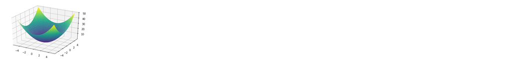

```
<sympy.plotting.plot.Plot at 0x7f988904d160>
```

```python
plot3d(x**2+y**2, (x, -5, 5), (y, -5, 5))
```

1. Clasifique el punto crítico de la función de utilidad hallado antes.

#### Solución:

Recordemos que $$U(x,y,z)=-2x^2-4y^2-2z^3+2xy+150z+32x+54y+12$$ por lo tanto $$H(U)=\begin{bmatrix}-4&2&0\\ 2&-8&0\\ 0&0&-12z\end{bmatrix}$$ De modo que al evaluar en el único punto crítico que tenemos $(13,10,5)$ obtenemos

$$|H_1(13,10,5)|=|-4|=-4.$$

$$|H_2(13,10,5)|=\begin{vmatrix}-4&2\\2&-8\end{vmatrix}=28.$$ $$|H_3(13,10,5)|=\begin{vmatrix}-4&2&0\\ 2&-8&0\\ 0&0&-60\end{vmatrix}=-1680$$

Dado que $|H_1(13,10,5)|<0$, $|H_2(13,10,5)|>0$ y $(-1)^3|H_3(13,10,5)|>0$, el punto crítico resulta ser un máximo.

Al evaluar obtenemos que $U(13,10,5)=990$, es decir, la utilidad máxima es de 990 cuando los precios de los productos A, B y C son 13,10 y 5, respectivamente.

## Ejemplo

1. Hallar los máximos y mínimos locales de $$ F(x,y) = 2x^2 + 4xy + 4y^2 + 4x - 4y. $$

**Solución:**

Primero hallamos los puntos críticos de $F$. Esto es, encontramos las derivadas parciales de primer orden, se igualan a cero y se resuleve el sistema de ecuaciones.

$F_x = 4x + 4y + 4$, y $F_y = 4x +8y -4.$

Ahora se resuelve el sistema $$\left\{ \begin{array}{l} 4x+4y+4=0\\ 4x+8y-4=0 \end{array} \right.$$

(Recuerde que puede usar el comando *solve* para ralizar este proceso de la siguiente manera: **solve([4x+4y+4,4x+8y-4],[x,y])** ).

La solución de este sistema de ecuaciones es $x = -3, y= 2$.

Concluimos este paso diciendo que $(-3,2)$ es un punto crítico de $F$.

Ahora hallamos la Hessiana de $F$

$$H(F)=\begin{bmatrix}4&4\\4&8\end{bmatrix}$$

por lo tanto $$|H_1(-3,2)|=|4|=4.$$ $$|H_2(-3,2)|=\begin{vmatrix}4&4\\4&8\end{vmatrix}=16.$$

Como $|H_1(-3,2)|$ y $|H_2(-3,2)|$ son positivos podemos afirmar que el punto crítico es un mínimo y el valor de la función en dicho punto es $$F(-3,2)=-10.$$

1. El siguiente ejemplo es muy importante para visualizar un tipo de puntos críticos, los puntos de silla. Clasifique los puntos críticos de la función $$f(x,y)=x^2-y^2$$

#### Solución:

Lo primero que debe realizarse es hallar las derivadas parciales de primer orden y resolver el sistema. $$\begin{cases}2x=0\\-2y=0\end{cases}$$ El cual tiene una solución $(0,0)$.

La Hessiana queda así: $$H(f)=\begin{bmatrix}2&0\\0&-2\end{bmatrix}$$ de donde $$|H_1(0,0)|=|2|=2$$ $$|H_2(0,0)|=\begin{vmatrix}2&0\\0&-2\end{vmatrix}=-4$$

Como los determinantes no cumplen con los criterios vistos, no podemos afirmar nada por el momento, pero al graficar la función

[figure not shown]

Entendemos un poco más el comportamiento de éste tipo de puntos y son los que por una trayectoria son mínimos (morada) y en otra máximos (roja), por la forma reciben el nombre de puntos de silla, haciendo referencia a la silla de montar.

## Ejemplo

Hallar los máximos y mínimos locales de $$ f (x, y) = -\frac{1}{3}x^3 + 4xy - 2y^2 + 1$$

**Solución:**

Primero hallamos los puntos críticos de $F$. Esto es, encontramos las derivadas parciales de primer orden, se igualan a cero y se resuleve el sistema de ecuaciones.

$f_x = -x^2 + 4y$, y $f_y = 4x - 4y.$

Ahora se resuelve el sistema $$\left\{ \begin{array}{l} -x^2 + 4y = 0, \\ 4x - 4y = 0. \end{array} \right.$$

Las soluciones de este sistema de ecuaciones son: $(0,0)$ y $(4,4)$, de modo que $f$ tiene dos puntos críticos.

Ahora calculamos las derivadas de segundo orden de $f$

$$f_{xx}(x,y) = -2x, \ \ \ f_{yy}(x,y) = -4, \ \ \ f_{xy}(x,y) = 4.$$

Así la Hessiana de $f$ viene dada por: $$H(f)=\begin{bmatrix}-2x&4\\4&-4\end{bmatrix}$$ de modo que: $$|H_1(0,0)|=|-2(0)|=0$$ $$|H_2(0,0)|=\begin{vmatrix}-2(0)&4\\4&-4\end{vmatrix}=-16$$ Como el valor de $|H_2(0,0)|$ negativo, el punto crítico es un punto de silla, y su valor es: $$f(0,0)=1$$

Para el otro punto crítico se tiene que

$$|H_1(4,4)|=|-2(4)|=-8$$$$|H_2(4,4)|=\begin{vmatrix}-2(4)&4\\4&-4\end{vmatrix}=16$$

por lo que el punto crítico cumple con la condición para ser un máximo, y su altura será $$f(4,4)=\frac{35}{3}.$$

### Ejercicios

Clasifique los puntos críticos de las funciones:

1. $f(x,y)=x^2+2y^2-2x-2y+1$.
2. $g(x,y)=x^2+4xy+y^2$.
3. $h(x,y)=-x^4-32x+y^3-12y+7$.
4. $j(x,y,z)=x^2+y^2+z^2+xy$.